# Tugas 1 — Pengantar Analisis Data Kategori

Latihan Analisis Data dengan R dan Quarto

Mahasiswa

Zibrija Tsamratul Qalbi Tasrif

NIM

241061006

Kode Tugas

ADK1-070181B1

**Tujuan tugas.** Gunakan kembali konsep dan fungsi R yang telah dibahas pada Pertemuan 1 untuk mengenali struktur data kategori, membuat ringkasan deskriptif, memvisualisasikan data, dan menjelaskan insight secara hati-hati.

**CatatanPola kerja**

Ikuti pola kelas: **predict → run → inspect → explain**.

Pada setiap bagian diberikan **sedikit petunjuk kode**.  
Jika diminta menjelaskan atau menuliskan interpretasi, gunakan kotak **Jawaban Anda** yang telah disediakan.

# 1 1. Mengenali Data

Gunakan R untuk melihat beberapa baris awal, struktur data, dan nama variabel.

**TipPetunjuk kode**

```r
head(...)
str(...)
names(...)
```

Ganti `...` dengan objek data yang digunakan.

```r
#head(data)
str(data)
```

```
'data.frame':   93 obs. of  9 variables:
 $ RecordID         : int  992898 593424 391508 427026 138534 762119 598783 577810 977112 276345 ...
 $ ProgramStudi     : chr  "Sains Aktuaria" "Sains Aktuaria" "Sains Data" "Sains Data" ...
 $ Gender           : chr  "P" "P" "L" "L" ...
 $ DeviceUtama      : chr  "Laptop" "Laptop" "Laptop" "Tablet" ...
 $ ModaBelajar      : chr  "Video" "Buku" "Diskusi" "Buku" ...
 $ Kepuasan         : chr  "Cukup" "Tidak Puas" "Tidak Puas" "Sangat Puas" ...
 $ IntensitasBelajar: chr  "Tinggi" "Rendah" "Sedang" "Tinggi" ...
 $ DurasiBelajarJam : num  9.4 2.1 8.1 10.8 4.8 9.5 12 6 7.1 6.5 ...
 $ PaketID          : chr  "ADK1-070181B1" "ADK1-070181B1" "ADK1-070181B1" "ADK1-070181B1" ...
```

```r
names(data)
```

```
[1] "RecordID"          "ProgramStudi"      "Gender"
[4] "DeviceUtama"       "ModaBelajar"       "Kepuasan"
[7] "IntensitasBelajar" "DurasiBelajarJam"  "PaketID"
```

Lengkapi tabel berikut.

[output not shown]

Jawab singkat:

1. Variabel mana yang merupakan identifier?
2. Variabel mana yang bersifat ordinal?
3. Mengapa kode angka belum tentu berarti data numerik?

**Jawaban Anda**

1. RecordID dan PaketID
2. Kepuasan dan IntensitasBelajar
3. Karena angka di dalam komputer/dataset kadang hanya berfungsi sebagai simbol atau label kategori (skala nominal/ordinal) saja, bukan untuk dihitung secara matematis (seperti dijumlahkan atau dirata-rata).

# 2 2. Menyiapkan Data Kategori

Variabel latihan Anda:

```r
cat("Nominal :", identitas$nominal_utama[1], "\n")
```

```
Nominal : Gender
```

```r
cat("Ordinal :", identitas$ordinal_utama[1], "\n")
```

```
Ordinal : IntensitasBelajar
```

```r
cat("Urutan  :", identitas$urutan_ordinal[1], "\n")
```

```
Urutan  : Rendah|Sedang|Tinggi
```

Lakukan hal berikut:

1. ubah variabel nominal menjadi factor;
2. ubah variabel ordinal menjadi ordered factor;
3. periksa level kategorinya.

**TipPetunjuk kode**

Untuk nominal:

```r
factor(...)
levels(...)
```

Untuk ordinal:

```r
factor(..., levels = ..., ordered = TRUE)
```

```r
nominal_var <- identitas$nominal_utama[1]
ordinal_var <- identitas$ordinal_utama[1]
urutan <- strsplit(identitas$urutan_ordinal[1], "\\|")[[1]]

data[[nominal_var]] <- factor(data[[nominal_var]])
levels(data[[nominal_var]])
```

```
[1] "L" "P"
```

```r
data[[ordinal_var]] <- factor(data[[ordinal_var]], levels = urutan, ordered = TRUE)
levels(data[[ordinal_var]])
```

```
[1] "Rendah" "Sedang" "Tinggi"
```

Tuliskan satu kalimat: **mengapa urutan level ordinal perlu ditetapkan dengan benar?**

Urutan level ordinal perlu ditetapkan dengan benar agar komputer dapat mengenali tingkatan atau hierarki data secara logis (misalnya dari yang terendah ke tertinggi), sehingga analisis statistik dan penyajian grafik tidak tertukar atau salah interpretasi.

# 3 3. Quality Control Awal

Lakukan pemeriksaan sederhana terhadap:

- struktur data;
- level/kategori;
- missing value;
- konsistensi penulisan kategori.

**TipPetunjuk kode**

Beberapa pola fungsi yang dapat digunakan:

```r
str(...)
levels(...)
unique(...)
is.na(...)
colSums(...)
```

Pilih fungsi yang sesuai dengan tujuan pemeriksaan Anda.

```r
str(data)
```

```
'data.frame':   93 obs. of  9 variables:
 $ RecordID         : int  992898 593424 391508 427026 138534 762119 598783 577810 977112 276345 ...
 $ ProgramStudi     : chr  "Sains Aktuaria" "Sains Aktuaria" "Sains Data" "Sains Data" ...
 $ Gender           : Factor w/ 2 levels "L","P": 2 2 1 1 2 2 1 1 1 1 ...
 $ DeviceUtama      : chr  "Laptop" "Laptop" "Laptop" "Tablet" ...
 $ ModaBelajar      : chr  "Video" "Buku" "Diskusi" "Buku" ...
 $ Kepuasan         : chr  "Cukup" "Tidak Puas" "Tidak Puas" "Sangat Puas" ...
 $ IntensitasBelajar: Ord.factor w/ 3 levels "Rendah"<"Sedang"<..: 3 1 2 3 2 2 3 2 2 1 ...
 $ DurasiBelajarJam : num  9.4 2.1 8.1 10.8 4.8 9.5 12 6 7.1 6.5 ...
 $ PaketID          : chr  "ADK1-070181B1" "ADK1-070181B1" "ADK1-070181B1" "ADK1-070181B1" ...
```

```r
unique(data$Kepuasan)
```

```
[1] "Cukup"       "Tidak Puas"  "Sangat Puas" "Puas"        NA
```

```r
colSums(is.na(data))
```

```
         RecordID      ProgramStudi            Gender       DeviceUtama
                0                 0                 0                 1
      ModaBelajar          Kepuasan IntensitasBelajar  DurasiBelajarJam
                0                 1                 1                 0
          PaketID
                0
```

Tuliskan **dua temuan singkat** dari pemeriksaan tersebut.

**Jawaban Anda**

1. Terdapat nilai kosong (missing value / NA) pada kolom DeviceUtama dan Kepuasan (masing-masing 1 data).
2. Variabel kategori seperti Kepuasan memiliki variasi kategori respons yang lengkap beserta nilai NA di dalamnya..

# 4 4. Frekuensi dan Proporsi

Sebelum menjalankan kode, prediksi:

> Menurut Anda, kategori mana yang paling banyak muncul pada variabel nominal Anda?

**Prediksi Anda**

Kategori “P” (atau seimbang antara “L” dan “P”, namun kita asumsikan salah satu kategori dominan berdasarkan sebaran sampel).

Setelah itu, buat:

- tabel frekuensi untuk variabel nominal;
- proporsi untuk variabel ordinal.

**TipPetunjuk kode**

```r
table(...)
prop.table(...)
```

Anda dapat menyimpan hasil `table()` ke sebuah objek terlebih dahulu sebelum menghitung proporsi.

```r
table(data[[nominal_var]])
```

```
 L  P
54 39
```

```r
prop.table(table(data[[ordinal_var]]))
```

```
   Rendah    Sedang    Tinggi
0.2826087 0.3586957 0.3586957
```

Tuliskan **dua kalimat insight** berdasarkan output.

# 5 5. Tabel Silang

Pasangan variabel Anda:

```r
x <- identitas$tab_baris[1]
y <- identitas$tab_kolom[1]

cat("Baris :", x, "\n")
```

```
Baris : Gender
```

```r
cat("Kolom :", y, "\n")
```

```
Kolom : ModaBelajar
```

Buat tabel silang untuk kedua variabel tersebut.

Jika diperlukan, tampilkan proporsi per baris untuk membantu membaca pola.

**TipPetunjuk kode**

```r
table(..., ...)
prop.table(..., margin = 1)
```

Lengkapi sendiri objek yang diperlukan.

```r
tabel_silang <- table(data[[x]], data[[y]])
tabel_silang
```

```
    Buku Diskusi Praktik Video
  L   21      18       9     6
  P   15      13       7     4
```

```r
prop.table(tabel_silang, margin = 1)
```

```
         Buku   Diskusi   Praktik     Video
  L 0.3888889 0.3333333 0.1666667 0.1111111
  P 0.3846154 0.3333333 0.1794872 0.1025641
```

Tuliskan **satu kalimat** yang menjelaskan pola yang tampak.

**Interpretasi Anda**

Baik responden laki-laki (L) maupun perempuan (P) sama-sama menunjukkan preferensi tertinggi pada metode belajar “Buku” dan terendah pada “Video”.

**Penting**

Gunakan bahasa deskriptif. Jangan langsung menyimpulkan adanya hubungan signifikan atau sebab-akibat.

# 6 6. Visualisasi Kategorik

Variabel yang divisualisasikan:

```r
v <- identitas$visualisasi[1]
cat("Variabel grafik :", v, "\n")
```

```
Variabel grafik : Gender
```

Buat **satu grafik batang** seperti yang telah dipelajari pada Pertemuan 1.

**TipPetunjuk kode**

```r
library(ggplot2)

ggplot(..., aes(x = ...)) +
  geom_bar() +
  labs(...)
```

Sesuaikan objek data, variabel, judul, dan label sumbu.

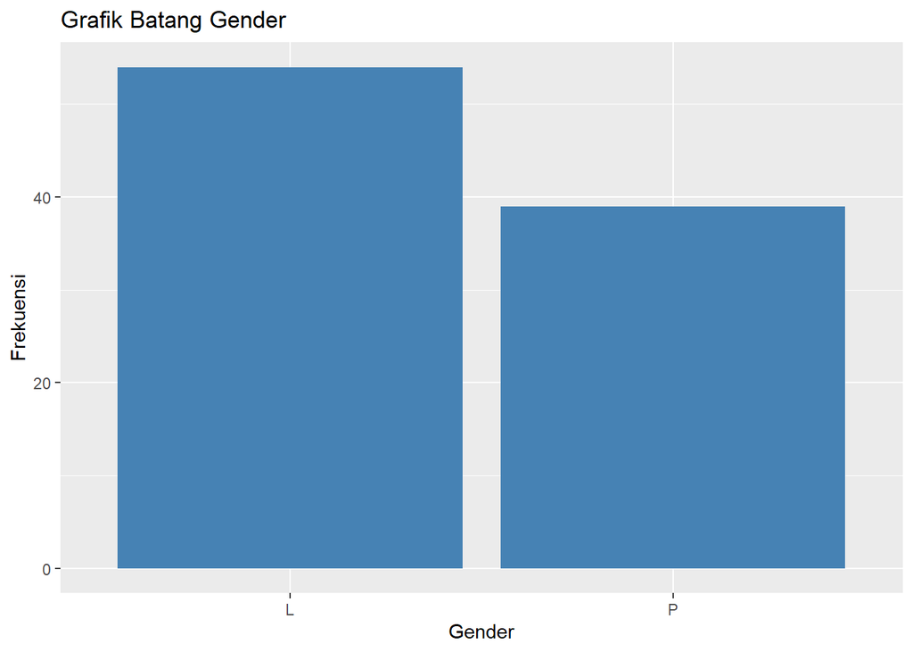

```r
library(ggplot2)

ggplot(data, aes(x = .data[[v]])) +
  geom_bar(fill = "steelblue") +
  labs(title = paste("Grafik Batang", v),
       x = v,
       y = "Frekuensi")
```

Tuliskan **satu kalimat** interpretasi grafik.

**Interpretasi Anda**

Jumlah responden berjenis kelamin laki-laki (L) lebih banyak dibandingkan perempuan (P) dalam data sampel ini.

# 7 7. Kesimpulan

Tuliskan **3 poin kesimpulan singkat** berdasarkan hasil analisis.

Setiap kesimpulan harus:

- didukung oleh output yang telah Anda hasilkan;
- menggunakan angka yang relevan;
- ditulis dengan bahasa Anda sendiri;
- tidak menggunakan klaim sebab-akibat.

**Kesimpulan Anda**

1. Berdasarkan analisis frekuensi dan visualisasi data, responden dengan jenis kelamin laki-laki (L) mendominasi dengan jumlah 54 orang dibandingkan perempuan (P) sebanyak 39 orang.
2. Intensitas belajar mahasiswa terbagi cukup seimbang, di mana kategori “Sedang” dan “Tinggi” memiliki proporsi tertinggi yang sama besar (~35.87%).
3. Berdasarkan tabel silang antara jenis kelamin dan moda belajar, baik responden laki-laki maupun perempuan sama-sama menunjukkan preferensi tertinggi pada metode belajar “Buku” dan terendah pada “Video”..

**Analisis Data Kategori — Tugas 1**  
Predict → Run → Inspect → Explain